# Visualizing St. Lawrence University Registration Data

Author

Kasey Wood

## Introduction and Background

St. Lawrence University is a private institution located in Canton, NY. With around 2,250 students enrolled on campus each year, there are many disciplines, course options, and routes to take for new students. Students may meet with their advisers to help guide them on the correct path of courses, or they may choose to guide themselves. Every student goes through the registration process themselves, however. And every professor is on the receiving end of that registration process. At St. Lawrence there are three days of registration for students. On the first day a student may choose their first class, then they may choose their second on the second day, and lastly on the third day the student may choose their last two classes and any lab they may want to take. Professors often put caps on their courses depending on the course and/or the classroom they will be in for that course. This leaves students with one of the most daunting questions, which course do I choose first?

## App Graphics (Static Versions)

### Notes about the Data

- Cross-listed course enrollment refers to the combined total enrollment of all cross-listed courses.
- COVID-19 section numbers are off, therefore Fall 2020, Spring 2021, and Summer 2021 are omitted from the data.

### Enrollment by Course

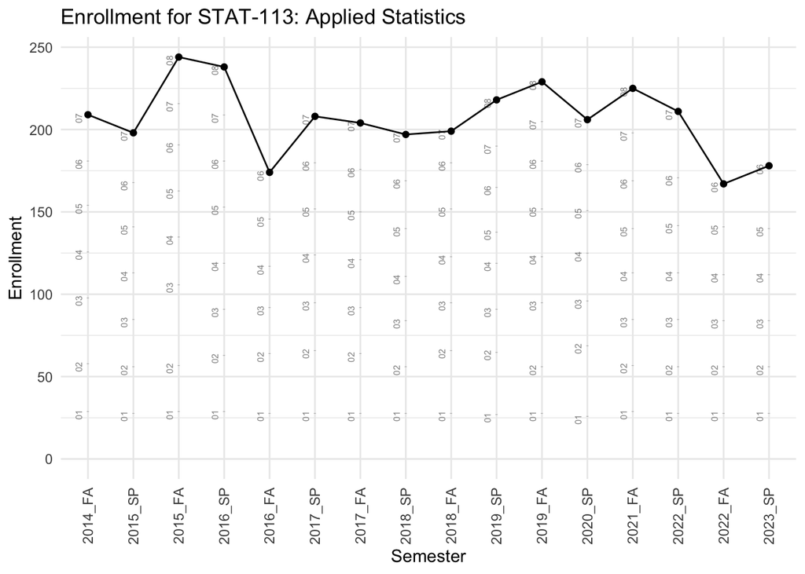

This is a static version of a graphic displayed in the shiny app. In the app, the user can choose to look at this graphic by semester or by year for the x- variable. In addition the user is able to use the graph settings button to omit covid years for both the year and semester graphs. If the user chooses the semester time frame, then settings to view sections on the graph are displayed. The graphic above shows a semester time frame, with the sections marked and labeled, for STAT-113: Applied Statistics.

### Enrollment by Discipline

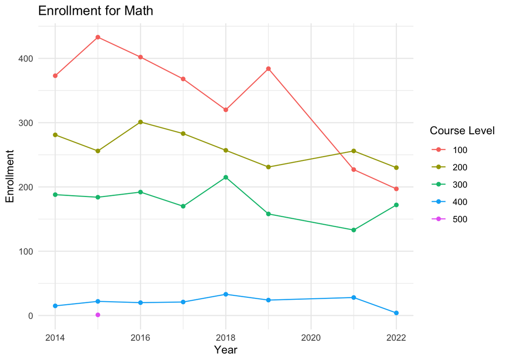

### Course Capacity

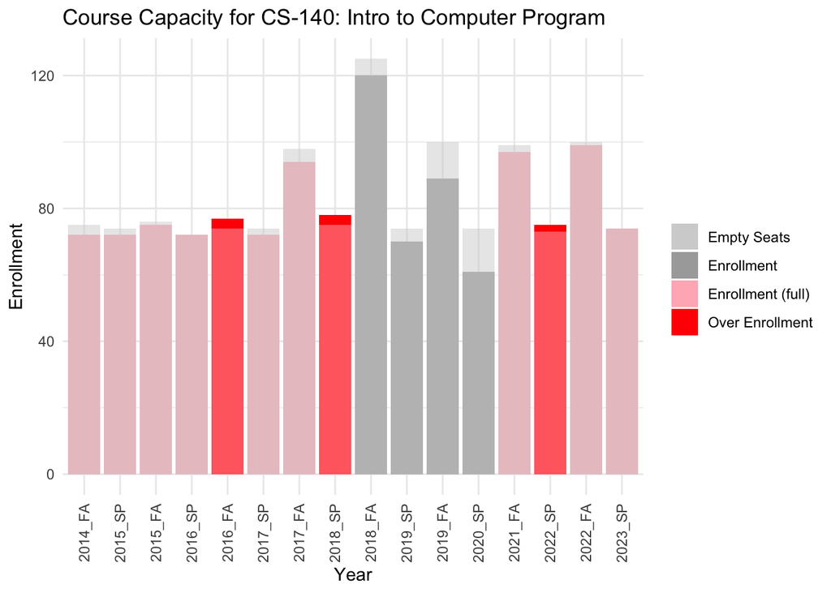

### The App

An example of the user interface on the app is shown below.

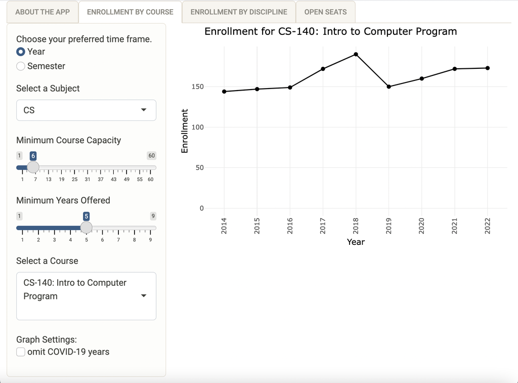

As seen above, the user has the option to choose the time frame of the graph. In addition to three settings that will change the course options (Select the Subject, Minimum Course Capacity, Minimum Years Offered). The select the subject button will filter only the subject selected in the course options button. If the user wants to specify minimum course capacity in order to extract courses that may be independed studies this is an option with the minimum course capacity slider. The user may also choose to only see courses offered a certain number of years with the minimum years offered button. There is a setting to omit the COVID-19 year on every graph in the app. There are extra settings the add labels and ticks for the sections on the semester enrollment by course graph.

## Appendix

### Tidying the Data

The St. Lawrence Registration data ranges from 2014 to 2022 and contains 61 variables.

Example of the beginning dataset:

```
# A tibble: 6 × 61
  `Acad Year Term` `Reporting Year` `Course Key` `Course ID` `Course Section ID`
  <chr>                       <dbl> <chr>        <chr>       <chr>
1 2014FA                       2014 2014FA-AAH-… 1928        459
2 2014FA                       2014 2014FA-AAH-… 1928        460
3 2015FA                       2015 2015FA-AAH-… 1928        3516
4 2015FA                       2015 2015FA-AAH-… 1928        3517
5 2016FA                       2016 2016FA-AAH-… 1928        7994
6 2016FA                       2016 2016FA-AAH-… 1928        7995
# ℹ 56 more variables: `Course Section Name` <chr>, `Course Name` <chr>,
#   Subject <chr>, `Course Number` <chr>, `Section Number` <chr>,
#   `Course Title` <chr>, Credits <dbl>, `xlist Primary Course` <chr>,
#   `xlist Section1` <chr>, `xlist Section2` <chr>, `xlist Section3` <chr>,
#   `xlist Section4` <lgl>, Enrolled <dbl>, Instructor1 <chr>,
#   Instructor2 <chr>, Instructor3 <lgl>, Instructor4 <lgl>,
#   `Course Level1` <chr>, `Course Level Desc1` <chr>, `Course Level2` <chr>, …
```

This data set did not include the course capacity, however we recieved this data from a separate data set as shown:

```
# A tibble: 6 × 5
  `Section ID` `Section Name` `Section Number` `Section Capacity` ...5
  <chr>        <chr>          <chr>                         <dbl> <lgl>
1 6            SOC-101-01     01                               30 NA
2 8            SOC-101-02     02                               29 NA
3 9            SOC-112-01     01                               30 NA
4 10           SOC-161-01     01                               30 NA
5 11           SOC-187-01     01                               30 NA
6 12           ENVS-187-01    01                               30 NA
```

I then joined these two datasets using a left_join and using the course section id as the key.

In order to wrangle to dataset to be more usable for visualizations, the full data set was trimmed down to key variables. These key variables include Acad Year Term, Reporting Year, Course ID, Course Name, Subject, Course Number, Course Title, Enrolled, xlist variables, Section Number, and Section Capacity.

The code used to fix this is below.

```r
course_reg_xlist <- course_reg_data |> drop_na(`xlist Section1`)
course_reg_xlist <- course_reg_xlist |> group_by(`Course Title`, section, `Reporting Year`) |> mutate(enrolled = sum(Enrolled)) |> select(-Enrolled) |> rename("Enrolled" = "enrolled") |>
  unite("course", c(`Course Name`, `Course Title`), sep = ": ")
course_reg_noxlist <- course_reg_data |> filter(is.na(`xlist Section1`)) |> unite("course", c(`Course Name`, `Course Title`), sep = ": ")
course_reg_data <- full_join(course_reg_xlist, course_reg_noxlist)
course_reg_data <- course_reg_data |> group_by(course, `Reporting Year`) |>
  mutate(yearly_capacity = sum(`Section Capacity`, na.rm = TRUE))
```

As shown in the code, the data was grouped by course (so every course that was cross-listed is grouped with it’s cross-listed course) and for each year, then added together to get the total enrollment. The mutate function allows that total enrollment to show up for each data point. The non-xlist data set was unchanged except for the course variable that would be used to help unite the data set.

After the dataset had accurate enrollment numbers for how it would be used within the app, the next step was to wrangle the data so there was only one data point for each course every year. This data set needed to include both fall_enrollment and spring_enrollment for that year along with the yearly_enrollment. It also needed to include the enrollment for each section every semester, so a sectioned graph could be made. After this was done by grouping the data in different ways and summing the enrollment for different time periods and sections, the dataset was usable within the app.

The dataset used within the app is shown below:

```
# A tibble: 6 × 48
  course      reporting_year yearly_enrolled fall_enrolled spring_enrolled FA_01
  <chr>                <dbl>           <dbl>         <dbl>           <dbl> <dbl>
1 CS-140: In…           2014             144            72              72    24
2 CS-140: In…           2015             147            75              72    25
3 CS-140: In…           2016             149            77              72    25
4 CS-140: In…           2017             172            94              78    24
5 CS-140: In…           2018             190           120              70    25
6 CS-140: In…           2019             150            89              61    25
# ℹ 42 more variables: FA_02 <dbl>, FA_03 <dbl>, FA_04 <dbl>, FA_05 <dbl>,
#   FA_06 <dbl>, FA_07 <dbl>, FA_08 <dbl>, FA_09 <dbl>, FA_10 <dbl>,
#   SP_01 <dbl>, SP_02 <dbl>, SP_03 <dbl>, SP_04 <dbl>, SP_05 <dbl>,
#   SP_06 <dbl>, SP_07 <dbl>, SP_08 <dbl>, SP_09 <dbl>, SP_11 <dbl>,
#   SP_12 <dbl>, SP_13 <dbl>, SP_14 <dbl>, SP_15 <dbl>, SP_16 <dbl>,
#   SP_18 <dbl>, SP_19 <dbl>, FA_11 <dbl>, FA_12 <dbl>, FA_13 <dbl>,
#   FA_14 <dbl>, FA_15 <dbl>, FA_16 <dbl>, FA_17 <dbl>, FA_20 <dbl>, …
```

App Tutorial Link: https://youtu.be/Z0DFfgEXze8